# Rename clusters and build tree

Jeremy Miller

March 8, 2019

# Overview

This script reads in the data and assigned clusters, organizes the clusters into a dendrogram, renames the clusters to include class information and informative genes, and then plots the summary plots for inclusion in Figure 1.

If needed, set the working directory first: e.g. `setwd("C:/Users/jeremym/Desktop/VEN_TEST")`.

### Load the relevant libraries

```r
suppressPackageStartupMessages({
  library(VENcelltypes)
  library(WGCNA) # For vectorizeMatrix
  library(edgeR)
  library(matrixStats)
  library(feather)
  library(dendextend)
  library(ggplot2)
  library(dplyr)
  library(gplots)
})
```

[output not shown]

```r
options(stringsAsFactors=FALSE)
```

### Read in the data and metadata (including clusters)

These files are included as part of the R package installation.

```r
data(FI_layer5_count_data)
data(FI_layer5_sample_information)
exprData <- FI_layer5_count_data
Samp.dat <- FI_layer5_sample_information
```

### Determine top cluster marker genes here for building the tree and displaying in heatmaps and violin plots.

First subset the data only only included non-outlier clusters.

```r
clusterType = Samp.dat$cluster_type_label
cl          = Samp.dat$cluster_id
names(cl)   = colnames(exprData)
includeClas = c("inh","exc","glia")
excludeClas = sort(setdiff(clusterType,includeClas))
kpSamp      = !is.element(clusterType,excludeClas)
```

Get median expression per cluster and the proportions.

```r
normDat    = log2(cpm(exprData)+1)
colnames(normDat) = colnames(exprData)
exprThresh = 1
medianExpr = do.call("cbind", tapply(names(cl), cl, function(x) rowMedians(normDat[,x])))
propExpr   = do.call("cbind", tapply(names(cl), cl, function(x) rowMeans(normDat[,x]>exprThresh)))
rownames(medianExpr) <- rownames(propExpr) <- rownames(normDat)
clusterOrd = as.character(sort(unique(Samp.dat$cluster_id)))
clusterKp  = as.character(sort(unique(Samp.dat$cluster_id[kpSamp])))
medianExpr = medianExpr[,clusterOrd]
propExpr   = propExpr[,clusterOrd]
presentGn  = apply(medianExpr[,clusterKp],1,max)>0
```

Identify uninformative genes to exclude from the cluster names. We also exclude a set of known mitochondrial and ribosomal genes. Note that all genes are use for all marker gene (and other) computations.

```r
shinyFail    = (grepl("\\-",rownames(medianExpr)))|is.element(substr(rownames(medianExpr),1,1),0:9)
  # -'s don't plot correctly, numbers add an "X"
excludeGenes = sort(rownames(medianExpr)[grepl("LOC",rownames(medianExpr))|grepl("LINC",rownames(medianExpr))|
  grepl("FAM",rownames(medianExpr))|grepl("ORF",rownames(medianExpr))|grepl("KIAA",rownames(medianExpr))|
  grepl("FLJ",rownames(medianExpr))|grepl("DKFZ",rownames(medianExpr))|grepl("RNF",rownames(medianExpr))|
  grepl("RPS",rownames(medianExpr))|grepl("RPL",rownames(medianExpr))|shinyFail])  # Also exclude ribosomal genes
data(mito_genes)
excludeGenes = sort(unique(c(excludeGenes,mito_genes)))
keepGenes    = setdiff(rownames(medianExpr)[presentGn],excludeGenes)
```

Identify the most specific genes for each cluster for naming.

```r
topGenes <- getTopMarkersByProp(propExpr[keepGenes,clusterKp],1,NULL,
                                medianExpr[keepGenes,clusterKp],fcThresh=0.5,minProp=0.5)
topGenes
```

```
         1          2          4          6          7          8          9         12         13         14         15         18
     "SST"  "CARM1P1"    "CAPN5" "SLC38A11"    "WISP1"   "ETNPPL"    "WNT16"     "LIPH"      "VIP"   "CASC18"    "GABRQ"     "GPX3"
        19         21         22         26         31         32         34         35         36         37
   "GABRE"       "TF"    "GPNMB"     "ELL3"    "SMYD1"      "CRH"     "CD74"      "CFH" "TMEM255A"     "LIX1"
```

### Rename clusters following the conventions from the MTG paper.

This is the reference: https://www.biorxiv.org/content/10.1101/384826v1 (UPDATE)

First we need to build the cluster info table

```r
clusterInfoAll = updateAndOrderClusters(Samp.dat,topGenes=topGenes, classLevels=c(includeClas,excludeClas),regionNameColumn=NULL,newColorNameColumn="cluster_color",layerNameColumn=NULL)
sampleInfo  = as.data.frame(Samp.dat[kpSamp,])
clusterInfo = clusterInfoAll[is.element(clusterInfoAll$cluster_type_label,includeClas),]
clusterInfo
```

|  | cluster_id | cluster_label | cluster_color | cluster_type_label | cellmap_label | old_cluster_label | layer | topMatch | lrank |
| --- | --- | --- | --- | --- | --- | --- | --- | --- | --- |
| 1 | 36 | cl36_i7_TMEM255A_Igtp | #E7766E | inh | Cd34 | cl36_i7_NKX2-1_Igtp | 0 | Igtp | 1 |
| 2 | 32 | cl32_i11_CRH_Ndnf.Cxcl14 | #A26081 | inh | Ndnf.Car4 | cl32_i11_C1QL2_Ndnf.Cxcl14 | 0 | Ndnf.Cxcl14 | 2 |
| 3 | 13 | cl13_i24_VIP_Vip.Mybpc1 | #936E6E | inh | Vip.Gpc3 | cl13_i24_VIP_Vip.Mybpc1 | 0 | Vip.Mybpc1 | 3 |
| 4 | 9 | cl9_i29_WNT16_Pvalb.Rspo2 | #DB6C86 | inh | Pvalb.Rspo2 | cl9_i29_WNT16_Pvalb.Rspo2 | 0 | Pvalb.Rspo2 | 4 |
| 5 | 1 | cl1_i74_SST_Sst.Tacstd2 | #C3974C | inh | Sst.Cdk6 | cl1_i74_DCN_Sst.Tacstd2 | 0 | Sst.Tacstd2 | 5 |
| 7 | 31 | cl31_e11_SMYD1_L2.3.Otof | #737D6E | exc | L2.3.Otof | cl31_e11_SMYD1_L2.3.Otof | 0 | L2.3.Otof | 7 |
| 8 | 2 | cl2_e72_CARM1P1_L2.Ngb | #59E9DF | exc | L6.Syt17 | cl2_e72_ADAMTS9-AS1_L2.Ngb | 0 | L2.Ngb | 8 |
| 16 | 4 | cl4_e52_CAPN5_L5a.Deptor_Pacsin2 | #7C759F | exc | L5a.Syt17 | cl4_e52_CCDC68_L5a.Deptor_Pacsin2 | 0 | L5a.Deptor_Pacsin2 | 16 |
| 19 | 12 | cl12_e24_LIPH_L5a.Syt17 | #B8E48F | exc | L5a.Syt17 | cl12_e24_TRAV8-3_L5a.Syt17 | 0 | L5a.Syt17 | 19 |
| 20 | 15 | cl15_e23_GABRQ_L5b.Cdh13 | #92AD7D | exc | L5b.Cdh13 | cl15_e23_ITGA4_L5b.Cdh13 | 0 | L5b.Cdh13 | 20 |

[output cut: 12 more lines]

Next, we rename the clusters. This involves appending the top specific genes calculated above, with the cluster class type, and some pre-defined markers for cell classes (defined just below).

```r
### IMPORTANT: Genes used for broad class definitions.  ###
majorGenes  = c("GAD2","SLC17A7","C3","AQP4","CSPG4","OPALIN")
majorLabels = c("Inh","Exc","Micro","Astro","OPC","Oligo")
broadGenes  = c("C3","AQP4","CSPG4","OPALIN","LAMP5","VIP","SST","PVALB","LHX6","LINC00507","RORB","THEMIS","FEZF2","CTGF")
# Rename the clusters
keepGenes2  = c(keepGenes,majorGenes,broadGenes)
clusterKp   = clusterInfo$cluster_id
newCluster  = renameClusters(sampleInfo,clusterInfo, propExpr[keepGenes2,clusterKp], medianExpr[keepGenes2,clusterKp],
    propDiff = 0, propMin=0.4, medianFC = 1, layerNameColumn=NULL, excludeGenes = excludeGenes,
    majorGenes=majorGenes, majorLabels=majorLabels, broadGenes=broadGenes)
# Cluster name clean-up
newCluster <- gsub("  "," ",newCluster)        # Remove double spaces
newCluster <- gsub("VIP VIP","VIP",newCluster) # Don't need same gene twice
newCluster <- gsub("SST SST","SST",newCluster) # Don't need same gene twice
clusterInfo$cluster_label = newCluster[clusterInfo[,1]]
# Add top genes to cluster information
clustSplit            <- strsplit(clusterInfo$cluster_label," ")
clusterInfo$broadGene <- as.character(lapply(clustSplit,function(x) return(x[2])))
clusterInfo$topGene   <- as.character(lapply(clustSplit,function(x) return(x[length(x)])))
# Update sample info with new cluster labels
clusterId           <- clusterInfo$cluster_id
names(clusterId)    <- clusterLabel <- clusterInfo$cluster_label
names(clusterLabel) <- clusterInfo$old_cluster_label
sampleInfo$cluster_label = clusterLabel[sampleInfo$cluster_label]
```

We want the cluster order to match that from the MTG paper. Since cluster order does not affect computation, we will do that here by matching each FI cluster to each MTG cluster by correlating cluster medians, and then setting the order annd color of FI colors to match these matched types. Note that the previously numbered script must be run to covert the MTG data to the appropriate feather files before this section of the code will work.

```r
# Load the cluster info for MTG clusters
data("clusterInfoMTG.RData")
```

[output not shown]

```r
# Read in and format MTG medians
mediansMTG <- read_feather("MTG/medians.feather")
mediansMTG <- as.data.frame(mediansMTG)
rownames(mediansMTG) <- mediansMTG$gene
mediansMTG <- mediansMTG[,colnames(mediansMTG)!="gene"]
ord <- match(clusterInfoMTG$cluster_id,colnames(mediansMTG))
colnames(mediansMTG) <- clusterInfoMTG$cluster_label[ord]
mediansMTG <- log2(mediansMTG+1)
# Format FI medians
mediansFI <- medianExpr
mediansFI <- mediansFI[,clusterInfo$cluster_id]
ord <- match(clusterInfo$cluster_id,colnames(mediansFI))
colnames(mediansFI) <- clusterInfo$cluster_label[ord]
# Take all genes differentially expressed across clusters (FC>100) in both data sets as input
dif     <- 100
geneMTG <- rownames(mediansMTG)[apply(mediansMTG,1,function(x) diff(range(x)))>log2(dif)]
geneFI  <- rownames(mediansFI)[apply(mediansFI,1,function(x) diff(range(x)))>log2(dif)]
geneKp  <- sort(intersect(geneMTG,geneFI))
# Assign an MTG cluster to each FI cell based on correlation of DEX genes
corFM       <- cor(normDat[geneKp,],mediansMTG[geneKp,])
clusterMTGa <- colnames(corFM)[apply(corFM,1,which.max)]
clusterMTG  <- clusterMTGa[kpSamp]
clusterFI   <- sampleInfo$cluster_label
fclusterMTG <- factor(clusterMTG,levels=intersect(colnames(mediansMTG),clusterMTG))
fclusterFI  <- factor(clusterFI,levels=intersect(colnames(mediansFI),clusterFI))
# Match the MTG and FI clusters and plot the results
tabMF <- t(table(fclusterMTG,fclusterFI))
ord   <- order(-apply(tabMF,1,function(x){ x = x>=(max(x)/1.5); mean(cumsum(x/sum(x))); } ))
tabMF <- tabMF[ord,]
tabMF <- tabMF/apply(tabMF,1,max)
celMF <- round(100*tabMF/apply(tabMF,1,sum))
celMF[tabMF<1] = ""
arealMatch <- colnames(tabMF)[apply(tabMF,1,function(x) which.max(x)[1])]
names(arealMatch) <- rownames(tabMF)
mediansMTG_match <- mediansMTG[,arealMatch]
colnames(mediansMTG_match) <- names(arealMatch)
# Update cluster info to order and color clusters as with the MTG data set
clusterInfo               <- clusterInfo[match(rownames(tabMF),clusterInfo$cluster_label),]
clusterInfo$lrank         <- 1:dim(clusterInfo)[1]
clusterInfo$cellmap_label <- colnames(tabMF)[apply(tabMF,1,function(x) which.max(x)[1])]
colMTG  <- clusterInfoMTG$cluster_color[match(colnames(tabMF),clusterInfoMTG$cluster_label)]
colorFI <- apply(tabMF,1, function(x,col) mixColors(col,2,weights=x), colMTG)
clusterInfo$cluster_color <- colorFI
# Update sample info (cluster colors and cellmap info)  # NEED TO CHANGE TO SAMP.DAT
ord <- match(sampleInfo$cluster_label,clusterInfo$cluster_label)
sampleInfo$cluster_color <- clusterInfo$cluster_color[ord]
ord <- match(clusterMTG,clusterInfoMTG$cluster_label)
sampleInfo$cellmap_color <- clusterInfoMTG$cluster_color[ord]
sampleInfo$cellmap_label <- clusterInfoMTG$cluster_label[ord]
sampleInfo$cellmap_id    <- clusterInfoMTG$cluster_id[ord]
```

Plot the comparison between FI and MTG clusters. NOTE: This figure is currently not included in the paper. Instead we compare four data sets together using Seurat in figure 3, and perform a more focused FI vs. MTG comparison in figure 4.

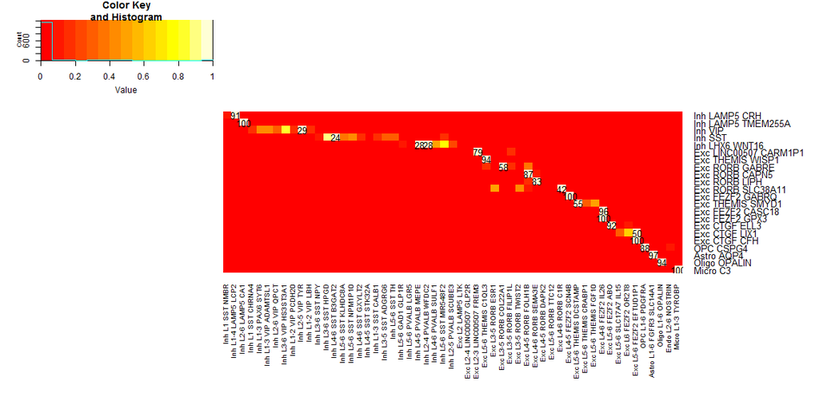

```r
heatmap.2(tabMF,trace="none",dendrogram="none",Rowv=FALSE,Colv=FALSE,margins=c(12,12),cellnote=celMF,notecol="black")
```

### Build clustering trees for nuclei based on the cluster calls

As with the MTG paper, we are only going to consider the top 1200 binary genes by beta for building the tree.

```r
# Determine a score for cell type specificity in non-outlier clusters (marker/beta score)
specificityScoreRank <- getBetaScore(propExpr[presentGn,clusterKp],FALSE)
topNgenes <- 1200
betaGenes <- names(specificityScoreRank)[specificityScoreRank<=topNgenes]
# Build and reorder the dendrogram
medianExpr2 <- medianExpr[betaGenes,match(clusterInfo$cluster_id,colnames(medianExpr))]
colnames(medianExpr2) <- clusterInfo$cluster_label
dend <- getDend(medianExpr2)
l.rank <- setNames(as.integer(clusterInfo$lrank), clusterInfo$cluster_label)
dend <- reorder.dend(dend,l.rank)
dend <- collapse_branch(dend, 0.01)
dend <- dend %>% set("leaves_pch", 19) %>% set("leaves_cex", 2)
```

Plot the result and save it to a pdf file.

```r
main = paste("Dendrogram based on top",topNgenes,"specificity genes, correlation distance")
label_color2 = clusterInfo$cluster_color[match(dend %>% labels,clusterInfo$cluster_label)]
rankCompleteDendPlot(dend=dend,label_color=label_color2,main=main,node_size=4)
pdf("clusterDendrogramFinal.pdf",height=10,width=12)
```

[figure not shown]

```r
label_color2 = clusterInfo$cluster_color[match(dend %>% labels,clusterInfo$cluster_label)]
rankCompleteDendPlot(dend=dend,label_color=label_color2,main=main,node_size=4)
dev.off()
```

### Save results for later and for plotting

The violin and heatmap functions require data to be in a specific feather format, and this section ensures that the outputted data is in the correct format.

```r
## Create a folder for these data
newInputFolder = "FI"
dir.create(newInputFolder)
```

```
'FI' already exists
```

```r
## Output the dendrogram
save(dend, file=paste0(newInputFolder,"/dend.rda"))
## Format and output the data
exprOut <- cpm(exprData)
colnames(exprOut) <- Samp.dat$sample_id
exprOut <- exprOut[,sampleInfo$sample_id]
exprOut <- as.data.frame(t(exprOut))
exprOut$sample_id <- sampleInfo$sample_id
write_feather(exprOut,paste0(newInputFolder,"/data.feather"))   # CPM
## Format and output the cluster information
clusterInfo = clusterInfo[match(labels(dend),clusterInfo$cluster_label),]
clusterInfo$cluster_id = 1:dim(clusterInfo)[1]
save(clusterInfo,file=paste0(newInputFolder,"/clusterInfo.rda"))
## Format and output the annotation information
ord <- match(sampleInfo$cluster_label,clusterInfo$cluster_label)
sampleInfo$cluster_id <- clusterInfo$cluster_id[ord]
write_feather(sampleInfo,paste0(newInputFolder,"/anno.feather"))
## Format and output a descriptor file for the annotations
cn   <- colnames(sampleInfo)[grepl("_label",colnames(sampleInfo))]
type <- rep("cat",length(cn))
for (i in 1:length(cn))
  if(is.numeric(as.data.frame(Samp.dat[,cn[i]])[,1]))
    type[i] = "num"
cn   <- gsub("_label","",cn)
desc <- data.frame(base=cn,name=cn,type = type)
write_feather(desc,paste0(newInputFolder,"/desc.feather"))
```

### Plot heatmap of broad genes and output results

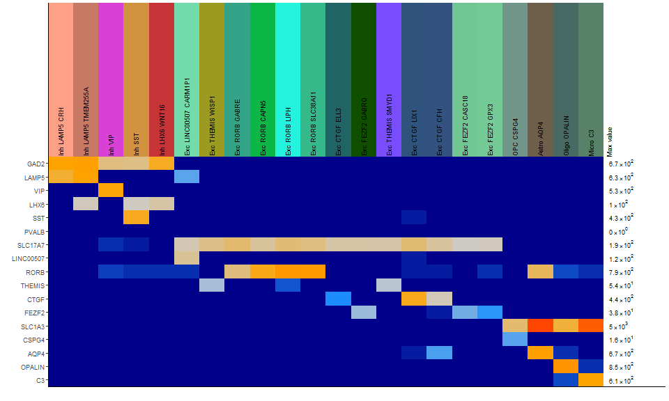

```r
all_clusters <- clusterInfo$cluster_id
broadGenes   <- c("GAD2","LAMP5","VIP","LHX6","SST","PVALB","SLC17A7","LINC00507",
                  "RORB","THEMIS","CTGF","FEZF2","SLC1A3","CSPG4","AQP4","OPALIN","C3")

broad_plot <- group_heatmap_plot(data_source = newInputFolder,
                   genes = broadGenes,
                   group_by = "cluster",
                   clusters = all_clusters,
                   calculation = "median",  # "trimmed_mean" in MTG paper
                   labelheight = 40,
                   showcounts = F)
broad_plot
```

```r
ggsave("Fig1_broad_markers.pdf",broad_plot,height = 4, width = 6)
```

### Violin plots of enriched genes for each excitatory cluster

We need to calculate a set of genes relatively enriched in each cluster. As a first step, we will exclude genes that have wildly high values in off-target cell types.

```r
# Get maximum expression per cluster (note medians and proportions previously calculated)
maxExpr <- do.call("cbind", tapply(names(cl), cl, function(x) rowMax(normDat[,x])))
rownames(maxExpr) <- rownames(propExpr)
maxExpr <- maxExpr[,colnames(propExpr)]
# Only consider genes where no cells have 1.5x higher expression that the highest expression in the most common cluster
maxExpr2  <- maxExpr[,clusterKp]
for (i in 1:length(maxExpr2[,1])) maxExpr2[i,which.max(propExpr[i,clusterKp])] = maxExpr2[i,which.max(propExpr[i,clusterKp])]*1.5
bestGenes <- apply(maxExpr2,1,which.max)==apply(propExpr[,clusterKp],1,which.max)
```

Next, find the top marker genes for each excitatory cluster.

```r
kpEx        <- as.character(cl[match(clusterInfo$old_cluster_label,Samp.dat$cluster_label)])
kpEx        <- intersect(kpEx,cl[clusterType=="exc"])
topGenesExc <- getTopMarkersByProp(propExpr[bestGenes,kpEx],4,NULL,medianExpr[bestGenes,kpEx],fcThresh=0.5,minProp=0.5)
topGenesExc <- vectorizeMatrix(t(topGenesExc))
topGenesExc <- formatPlotGenes(topGenesExc)  # Format genes to be compatible with plotting function
```

Next, make the plots!

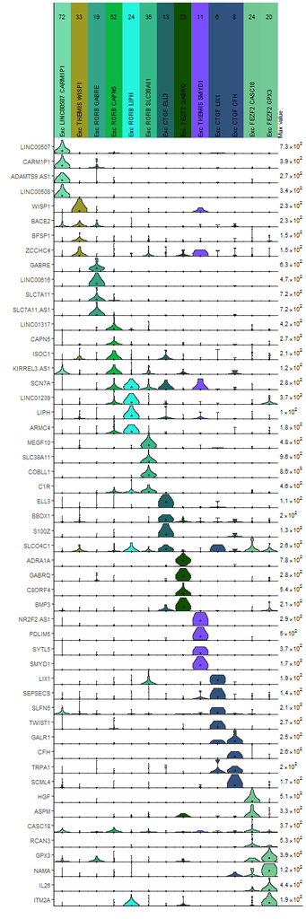

```r
kp <-  clusterInfo$cluster_type_label=="exc"
exc_plot <- group_violin_plot(data_source = newInputFolder, clusters=all_clusters[kp], genes=topGenesExc,labelheight = 15)
exc_plot
```

Finally, save the plots!

```r
ggsave("Fig1_exc_violinPlots_specificGenes.pdf", width = 5, height = 15)
```

### Violin plots of validated genes

In our study we valided expression of several genes in layer 5 of FI. Here is the expression of those genes in excitatory types.

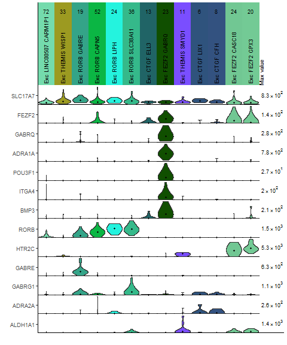

```r
valGenes <- c("SLC17A7","FEZF2","GABRQ","ADRA1A","POU3F1","ITGA4","BMP3","RORB","HTR2C","GABRE","GABRG1","ADRA2A","ALDH1A1")
kp <-  clusterInfo$cluster_type_label=="exc"
val_plot <- group_violin_plot(data_source = newInputFolder, clusters=all_clusters[kp], genes=valGenes,labelheight = 25)
val_plot
```

Save the plots!

```r
ggsave("Fig2_violinPlots_validatedGenes.pdf", width = 5, height = 6)
```

### Violin plots of literature-based genes

Several studies have identified genes (or proteins) expressed in VENs using a variety of strategies. Here we will plot the expression of these genes in our data set to get a sense of how specific these genes are to a specific cluster. First, let’s see which of these genes are available for plotting in our study.

```r
literature <- c("VAT1L","CHST8","LYPD1","SULF2","BCL11B","FEZF2","SLC18A2","GABRQ","ADRA1A","ATF3","IL4R",
                "NMB","DISC1","VGF","ABAT","CBLN2","CHRM1","CHRNA4","CNR1","CRYM","DLD","GABBR1","GABRR2",
                "GABRA","GABRB2","GABRB3","GABRD","GLRB","GLS","GOT1","GOT2","GRIA1","GRIA2","GRIA3","GRIK2",
                "GRIN1","GRIN2A","GRIN2B","GRIN3A","HRH3","HTR3B","NEFH","NNAT","SCG2","SYT2","TAC1","NPY",
                "IGFBP2","MEF2C","CPLX1","MBP","PLP1","RNA5SP352","ACA64","ALKBH3","FABP6","PLP1","METRNL",
                "LINC00982","RNU6-1240P","RGMA","PRR5","HAPLN4","SOHLH1","HTR2B","DRD3","GRP","LMO4")
print(paste("Genes not in our data set:",paste(setdiff(literature,rownames(normDat)),collapse=", ")))
```

```
[1] "Genes not in our data set: GABRA, ACA64"
```

```r
literature <- intersect(literature,rownames(normDat))
```

```r
val2 <- 2*propExpr[literature,match("20",colnames(propExpr))] -
        apply(propExpr[literature,match(clusterInfo$cluster_id,colnames(propExpr))][,kp],1,quantile,0.75)
plotGenes <- names(sort(-(val2)))
```

Next, make the plots!

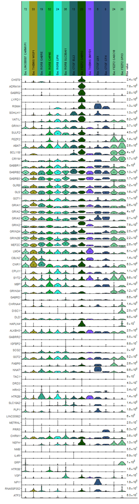

```r
kp <-  clusterInfo$cluster_type_label=="exc"
lit_plot <- group_violin_plot(data_source = newInputFolder, clusters=all_clusters[kp], genes=plotGenes,labelheight = 15)
lit_plot
```

Finally, save the plots!

```r
ggsave("FigS3_violinPlots_literatureVENgenes_excClusters.pdf", width = 5, height = 18)
```

Next, make the plots!

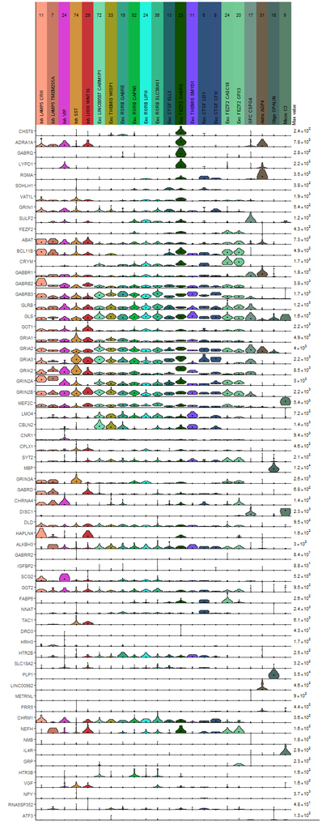

```r
lit_plot <- group_violin_plot(data_source = newInputFolder, clusters=all_clusters, genes=plotGenes,labelheight = 15)
lit_plot
```

Finally, save the plots!

```r
ggsave("FigS3_violinPlots_literatureVENgenes_allClusters.pdf", width = 7, height = 18)
```